# Neural_Net_Basics

### Review of a Derivative

**Question !**  
What is the derivative of the function $f(x) = 3x$ with respect to (w.r.t.) $x$?

**Question !**  
What is the derivative of the function $f(x) = 3x^2$ w.r.t. $x$?

**Question !**  
What does the derivative signify?

### Review of the Chain Rule (in 1-Dimension)

Again, let $f(x) = 3x^2$.  
But now, let x itself be a function which depends on another variable $y$.  
Suppose this function is $x = \frac{1}{2}y$

**Question !**  
First, verify that if you substitute in $\frac{1}{2}y$ for $x$ into the initial equation $f(x)$, then take the derivative w.r.t. $y$, you get $\frac{df}{dy} = \frac{3}{2}y$

The **Chain Rule** states the following:
For some function $f$ depending on $x$, which itself is a function which depends on $y$, then …
$$\frac{df}{dy} = \frac{df}{dx} \frac{dx}{dy}$$

**Question !**  
Use the Chain Rule to verify that $\frac{df}{dy} = \frac{3}{2}y$.

### Review of the Chain Rule (in Multi-Dim)

We will now verify the multi-variable/multi-dimension version of the Chain Rule with an example.  
This is needed to solve problems related to the Back-Propagation Algorithm later on.

Consider a function $f$ that depends on $x$ and $y$ as follows.  
$f := f(x,y) = 3x^2 + y$

Let $x$, $y$ both be functions of a variable $t$, $x(t) = 2t$ and $y(t) = t^2$.

Our goals is to solve for the derivative of $f$ w.r.t. $t$, aka $\frac{df}{dt}$.

**Question !**  
First, “brute force” the calculation for $\frac{df}{dt}$ by first substituting $x$ and $y$ back into the original equation for $f$.  
Then, take the derivative of $f$ w.r.t. $t$, aka $\frac{df}{dt}$.  
Verify that you get $\frac{df}{dt} = 26t$

The Chain Rule in Two Dimensions (can be extended to multiple) states the following:
For a function $f$ depending on $x$ and $y$, which themselves are both functions of $t$, then …
$$\frac{df}{dt} = \frac{\partial f}{\partial x} \frac{dx}{dt} + \frac{\partial f}{\partial y} \frac{dy}{dt}$$

**Question !!**  
Use the Chain Rule in 2-D to verify the same result, $\frac{df}{dt} = 26t$.  
Hint: after taking $\frac{\partial f}{\partial x}$, you are still left with an $x$ term. At this point, you can simply substitute $x$ in terms of $t$, since ultimately we want the derivative of $f$ w.r.t. $t$.

### How Does Gradient Descent Work?

Gradient Descent (GD) is an iterative algorithm that allows us to “travel” down a curve/function until we reach a minimum.  
In the ML context, we find GD applied to a cost function, since that is what we want to minimize 99% of the time.  
At each step, GD tweaks our parameter in a certain way (i.e. a certain direction) such tha value of your cost function with the new (tweaked) parameter will be a little bit closer to the minimum of the cost function.

More formally, steps of GD in the ML context are as follows. Suppose we pick some initial random values for our parameter(s) $\theta$, and we use these parameter(s) to calculate the value of our cost function, $C(\theta|data)$.

1. To get closer to a minimum value of the cost function, we calculate the gradient of the cost function with respect to $\theta$.
2. Next, we then move our parameters a certain distance in the direction OPPOSITE that of the gradient.
3. Then, we repeat the step 1) and step 2), and so on…

Step 2) and 3) in math notation: $\theta_{new} = \theta_{old} - \alpha \nabla C(\theta_{old})$

Note: $\alpha$ represents the magnitude of our move in the direction opposite the gradient. It is referred to as the “learning rate”.

While we mainly care about GD in the above context, it is hard to picture how gradient descent works since cost functions are usually a function of many parameters, and each parameter adds a new dimension to the input of our cost function.

I find it helpful to understand how GD works in a single dimension, for a function that is not a cost function.

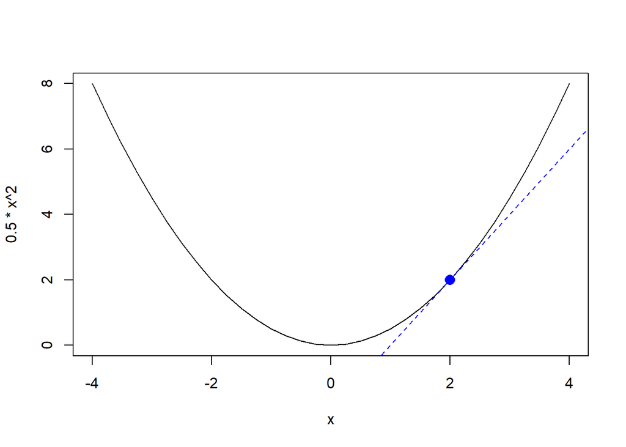

Let $f(x) = \frac{1}{2}x^2$

Assume that we are starting at the point $x = 2$.

**Question !**  
What is the minimum of this function?

**Question !**  
Set up GD for this function to find its minimum.  
Hints: Think back to GD in the cost function context and try to find parallels here.  
What is our “cost function”? It’s the function whose value we want to minimize. That’s just $f(x)$.  
What is our “parameter”? It’s the thing we tweak to get the minimum value of our function. So… $x$.  
What is our “data”? Trick question :-) this is not a cost function, so there is no data. But if we really want to force the analogy, I guess we could say the “data” is just the $\frac{1}{2}$ and $[]^2$ parts.

**Question !**  
The starting point is $x=2$. What is your initial function value?

**Question !!**  
Let’s run the GD algorithm for one step. What is your new parameter value? What is your new function value?  
Assume a learning rate $\alpha$ of 0.5 for this question.

Sometimes, it is helpful better grasp how something works by applying it outside of what we are familiar with.  
I hope the exercises above accomplished this for Gradient Descent by showing how this algorithm works outside of our traditional ML lens.

### Digging Deeper with Gradient Descent (Optional)

A common question asked is, “Why does GD tell us to move in the direction OPPOSITE the gradient?”  
Specifically, why does the algorithm say $- \alpha \nabla C(\theta_{old})$ instead of $+\alpha \nabla C(\theta_{old})$ ?

The textbook answer is because “the gradient gives us a direction of steepest ascent”. And since we want DESCENT, we subtract the gradient.  
But that’s unfulfilling if you ask me :-)  
So intead, let’s use a simple example to see the intuition behind this.

Same setup as before. Let $f(x) = \frac{1}{2}x^2$. Assume we start at $x = 2$, with a learning rate $\alpha = 0.5$.

**Question !**  
Suppose the math notation formula for GD is $x_{new} = x_{old} + \alpha \nabla f(x_{old})$. Run GD for one step. What is your value of $x_{new}$ under this formula?  
Pretend the math notation formula for GD is $x_{new} = x_{old} - \alpha \nabla f(x_{old})$. Run GD for one step. What is your value of $x_{new}$ under this formula?

**Question !**  
Under which math notation formula do you get closer to the minimum?

**Question !!**  
Based on your understanding of derivatives, think about what adding a derivative vs. subtracting a derivative means about how you are moving on the curve.

### Motivation for Stochastic Gradient Descent

Stochastic gradient descent (SGD) is another very useful algorithm in ML.  
At its core, SGD is just GD.  
But instead of taking your full population of data to find the gradient with respect to your parameters $\theta$ at each step, it only takes a subset of data each time to update $\theta$.  
This gives it a much higher computational efficiency and makes it a crucial foundation in building neural networks. Or until we have super-mega-ultra-quantum-squared computers, at least.

Let’s movitvate its usefulness/efficiency through an example.

**Question !**  
Suppose I give you 400 million and 1 observations of a random variable $X$. These sequence of observations goes from 1.98 up through 2.02 inclusive, with a step size of exactly 1E-10.  
Using your previous statistics knowledge, what is your best guess for the true value of this random variable?

You are a smart human. So this question was easily solvable despite the 400 million and 1 observations.  
But now, imagine you are a machine (insert Bert Kreischer joke here).  
Your cost function, the way you measure your performance (since you are a machine), is the squared error, i.e. $C(\hat{X}|data) = \sum_{i=1}^{400mm}(\hat{X} - X_i)^2$.

And you want to find the optimal value $\hat{X}$ that minimizes your cost function.

You start at a random guess for $\hat{X}$, say $\hat{X} = 20$.

**Question !!**  
How many calculations do you need to perform to complete one iteration of the GD algorithm and update $\hat{X}$? (Order of magnitude is fine)

**Question !!**  
Now, suppose you only chose a random subset of 400 points to calculate the cost function.  
So now, your cost function is $C(\hat{X}|data) = \sum_{j=1}^{400}(\hat{X} - X_j)^2$, where $j$ is a subset of $i$.  
How many calculations do you perform to complete one iteration of the GD algorithm and update $\hat{X}$? (Order of magnitude is fine). (Note: what you did here was SGD in a nutshell).

**Question !!**  
Imagine a different scenario, where I gave you observations of a random variable $X$ as follows… (-200, -100, -20, 24, 104, 204).  
I asked you again to use either GD or SGD to find me the value $\hat{X}$ that minimies the cost function. Which would you choose? And why?

Hopefully, these questions above gave an intuitive sense of how SGD works.  
The second question is meant to showcase a very compelling, if not obvious, use case.  
The third question tries to highlight its pitfalls.

### Neural Networks Introduction, Structure, + Notation

The below section contains no problems, but it is very useful for understanding neural networks / doing problems later on.

The neural networks (neural nets, NN) we learn this time around are called multi-layer perceptrons.  
Like all neural networks, they are models that work by feeding some data $x$ through a so-called network that takes the data and proceeds to make a prediction/decision. Each data point is usually multi-dimensional, i.e. $x=(x_1,x_2,...)$.

Let’s explore the neural network structure with this image of a neural network below.

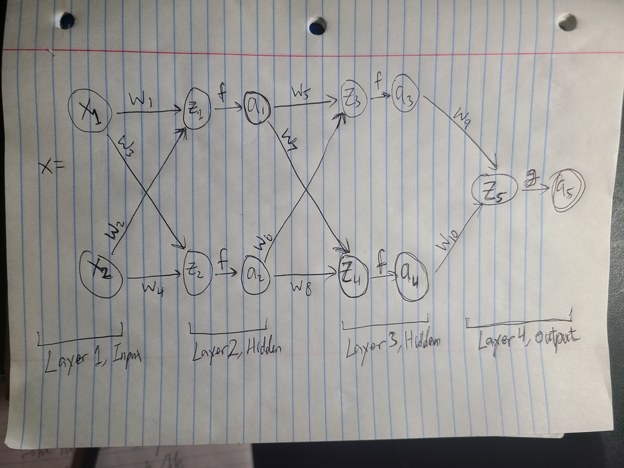

Neural Net Image

In this image, we are feeding a single 2-dimensional data point $x = (x_1, x_2)$ through a NN to try and get a prediction.

Just like how a signal from your hand travels through many layers of neurons before finally reaching your brain, **a neural network contains multiple layers which process the data and make a prediction**.

Our Neural Network has 4 **layers**. The input layer, two “hidden” layers, and the output layer. Aside from the input and output layer, all other layers of a neural network are “hidden” layers.

Each layer of the NN contains a bunch of cells called **nodes**. These are the $z_i$ the $a_i$.  
The $z_i$ are “unactivated” nodes. The $a_i$ are “activated” nodes.  
The “unactivated” nodes $z_i$ can be thought of as the dendrite part of the neurons in our body. They receive signals from nodes in the previous layer.

Some of these **signals** may be stronger, some may be weaker. The **signal strengths** coming from nodes in the previous layer are controlled by scalar **weights**, the $w_i$.

The final aggregated signal that reaches our current layer’s node is just a **linear combination** of the **previous nodes** (or more specifically the values of the nodes) and their respective **signal strengths** (i.e. the **weights**).  
So for example, $z_1 = w_1x_1 + w_2x_2$.

This aggregated signal is just the value of our (unactivated) **node** in our current layer, $z_i$.  
The way that a **node** in our current layer $z_i$ decides what signal/information to pass through is with a function called an **activation function**, denoted $f$ (and $g$) in the image.  
The function $f$ takes the “unactivated” node as an input, and and it ouputs an “activated” node.  
So for example, $f(z_2) = a_2$.

The **activation function** $f$ applies a non-linear transformation to the $z_i$.  
Common activation functions include:  
- the sigmoid $a_i = f(z_i) = \frac{1}{1+exp(-z_i)}$,  
- the hyperbolic tangent $f(z_i) = tanh(z_i)$,  
- the ReLU $f(z_i) = z_i, z_i > 0$ and $0$ otherwise.

$g$ is just the activation function for the output layer. $g$ may or may not equal $f$.  
For binary classification problems (i.e. we want model to predict a binary outcome), $g$ is usually the sigmoid function.

Note that in our NN (and all NN’s), it is the “activated” node values **$a_i$ that are used as inputs for the next layer of the NN**.  
They can be thought of like the axon part of a neuron.

The only exception to this rule is with nodes in the first layer (input layer).  
The values of the nodes in this layer are just the values of each dimension of our data point – $x_1$ and $x_2$.  
These raw values are used directly to calculate the aggregate signal for the (unactivated) nodes in the next layer.  
In other words, the input data will not be activated before it is used as a signal for the next layer.  
The value of the activated node of the last layer, $a_5$, gives us the output, or prediction of the NN.

**Recap:**  
Our one data point $x$ is 2-dimensional. Each dimension value is used as an input node in the first **layer** of our NN.  
The $w_i's$ are **weights**. They are the signal amplifiers/dampeners that help send the signal from one layer to the next.  
The $z_i's$ and $a_i's$ make up the **nodes** for a **layer**. The value of each node $z_i$ is just the aggregate signal of the previous layer sent to this node.  
The value (i.e. aggregate signal) for $z_i$ is a **linear combination** of the **nodes $a_j$ in the previous layer and their respective weights or signal strengths $w_j$**.  
The $z_i$ get “activated” by our **activation function** $f$. This turns the $z_i$ into $a_i$.  
$g$ is also an activation function, specifically for the output layer. $g$ may or may not equal $f$.  
The $z_i's$ are like the dendrites of a neuron. They receive signal from the $a_k$ nodes in the previous layer.  
The $a_i's$ are like the axons of a neuron. It is their their values that get sent to the $z_j$ nodes in the next layer.  
The $z_i$ and $a_i$ make up a **layer** of the NN.

### Neural Networks, the Forward Pass

Recall our 4-layer NN example.

We have a brand new data point $x = (x_1, x_2)$. The true outcome of this data point is $y$, a binary outcome.  
We first initialize some (random) values for the weights $w_i$.  
Let’s assume our activation functions $f$ and $g$ are both sigmoids, $f(x) = \frac{1}{1+exp(-x)}$  
Let us calculate what the prediction by our Neural Net for this data point will be.

**Question !**  
Based on the NN structure, write out the values of $z_1$ and $z_2$ as functions of $x_i's$ and $w_i's$.

**Question !!**  
Write out $a_1$ and $a_2$ as functions of the $z_i's$.  
Does $a_1$ *directly* depend on $w_2$?  
Does $a_1$ *indirectly* depend on $w_2$? If so, through what?  
Does $a_1$ *indirectly* depend on $w_4$? If so, through what?

**Question !**  
Write out $z_3$ and $z_4$ as functions of $a_i's$ and the $w_i's$. Do $z_3$ and $z_4$ *directly* depend on anything else?

**Question !**  
Write out $z_5$ as a function of $a_3$ and $a_4$. Write out $a_5$ in terms of $z_5$.

**Question !**  
What do $w_1$, $w_2$, …, $w_{10}$ depend on? Hint: The is a trick question.

Through this exercise, we performed a “forward pass” with our data in the Neural Network.  
It is exactly like it sounds. We passed our data point through every layer of our NN.

In each layer, the neural net took a linear combination of the signals from the previous layer and then transformed this aggregated signal into a new signal to pass onto the next layer.

We did this until we finally got $a_5$, the value of our output layer, i.e. the prediction of our NN.

Hooray!

### Neural Networks, Back-Propagation

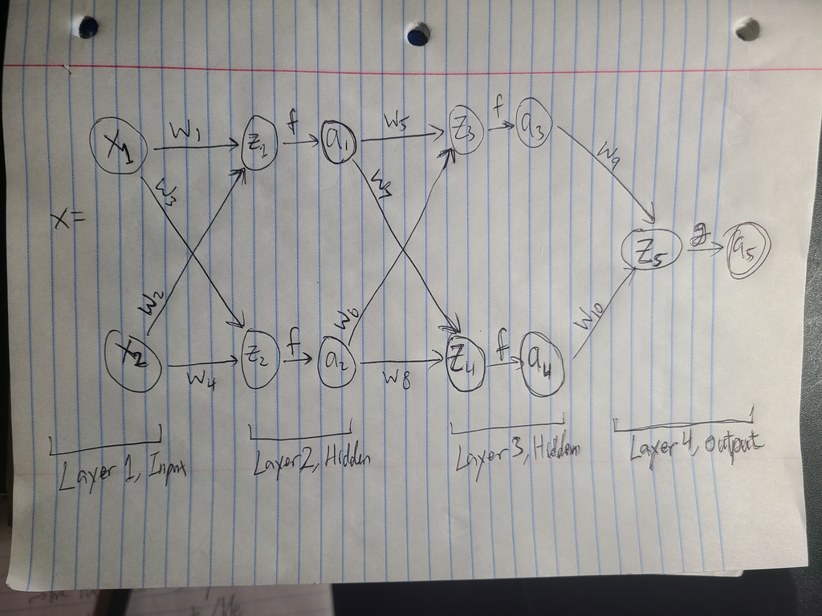

Neural Net Image

Perhaps we “Hooray!”-ed too soon.  
Recall our 4-layer NN above. In our setup, we started out by picking random weights $w_i$ for our NN. But these weights are probably horrible!  
Our output $a_5$, i.e. our prediction, probably doesn’t even come close to the true outcome of the data, $y$.

So, like all ML algorithms, we need to define our model performance using a cost function.  
And then we need to tweak our parameters $w_i's$ in the right direction get us closer to the minimum of this cost function.

What is our $\theta$, our parameters?  
For our Neural Net, the $w_i's$ are the only parameters that our neural net can tweak when trying to find the optimal of the cost function for our data.  
This is because the $w_i's$ don’t depend on anything else.  
Unlike the $z_i's$ or $a_i's$, they are not functions of anything. They just… are.

You might wonder, “What about the number of layers of the NN, or the number of nodes in each layer, or even the activation functions $f$ and $g$? Can’t we tweak these too?”  
Ye we can, but these are the *hyperparameters* of our Neural Net.  
Once these hyperparameters are “set” in our NN structure, they cannot be changed.

Now that we have established what our $\theta's$ are, let’s substitute it back into the cost function.  
So $C(\theta|y)$ becomes $C(w_i's|y) = (a_5 - y)^2$.

Like all ML, we want to improve our model prediction by minimizing our cost function through Gradient Descent.

Recall the general Gradient Descent formula from earlier, $\theta_{new} = \theta_{old} - \alpha \nabla C(\theta_{old})$.

This is a vector representation of Gradient Descent. But a gradient is the same thing as expressing–in a vector form–the partial derivatives of our cost function with respect to every single one of our parameters, our $w_i's$.

So, to apply GD to minimize the cost function of our NN, we need to calculate all 10 partials.  
Assume all activation functions are sigmoids.

Two More Notes:  
1) The derivative of a sigmoid function is $f'(x) = f(x)(1-f(x))$.  
2) Feel free to leave your answers in notation form as necessary. But for easy-to-calculate derivatives, please try to provide the derivative value and not the notation.

**Question !!**  
Let’s start with $w_9$. Calculate $\frac{\partial C(w_i's|y)}{\partial w_9}$  
Hint: Use the Chain Rule (1-dimensional case).  
Hint: Recall the Forward Pass exercise. How does $a_5$ depend on $w_9$? Does it depend directly on $w_5$?  
Hint: The answer is $2(a_5-y)g(z_5)(1-g(z_5))a_3$. See if you can verify.

**Question !**  
Confirm that in our NN structure, the partial with respect to $w_{10}$ has a similar setup.

**Question !!!**  
Next, let’s do $w_5$. calculate $\frac{\partial C(w_i's|y)}{\partial w_5}$.  
Hint: Use the Chain Rule (1-dimensional case).  
Hint: Recall the Forward Pass exercises. How does $a_5$ depend on $w_5$? Does it depend directly on $w_5$? Or does it depend on things that depend on things that… depend on $w_5$?  
Hint: The answer is $2(a_5-y)g(z_5)(1-g(z_5))w_9f(z_3)(1-f(z_3))a_1$. See if you can verify.

**Question !**  
Confirm that in our NN structure, the partials with respect to $w_6$, $w_7$, and $w_8$ have a similar setup.

**Question !!!! (CHALLENGE)**  
Now, let’s do $w_1$. calculate $\frac{\partial C(w_i's|y)}{\partial w_1}$.  
Hint: Use the Chain Rule (multi-dimensional case).  
Hint: Recall the Forward Pass exercise. Which node(s) in the 2nd layer depend(s) on $w_1$?  
Hint: Recall the Forward Pass exercise. Which node(s) in the 3rd layer depend(s) on $a_1$?  
Hint: There is a plus sign in the final answer. The first part of the sum is $2(a_5-y)g(z_5)(1-g(z_5))w_9f(z_3)(1-f(z_3))w_5f(z_1)(1-f(z_1))x_1$.  
See if you can verify, and also get the second part of the sum.

**Question !**  
Confirm that in our NN structure, the partials with respect to $w_2$, $w_3$, and $w_4$ have similar setups.

Wooohooo! Hooray! You did it, for real this time :-)  
What you did was apply the Back-Propagation algorithm layer by layer, by hand, to get the partials of each weight $x_i$ of your NN.  
Nice work again!

As stated above, the vector representation of your partials with respect to each $w_i$ is just the gradient of your parameters. In other words…
$$\nabla C(\theta) = \nabla C(w_{1}, w_{2},..., w_{10}) = (\frac{\partial C(w_i's|y)}{\partial w_1}, ..., \frac{\partial C(w_i's|y)}{\partial w_{10}})$$

Now you can update all 10 weights in your Neural Net using Gradient Descent, since you solved the gradient :-)

$\nabla C(w_{1,new}, w_{2,new}, ..., w_{10,new}) = \nabla C(w_{1,old}, w_{2,old}, ..., w_{10,old}) - \alpha \nabla C(w_{1,old}, w_{2,old}, ..., w_{10,old}))$.

Gradient Descent has now tweaked your weights $w_i's$ in a way that will improve your prediction for your data point $x$.  
Congratulations! You are one step closer to the optimal Neural Network for your data point.

### Neural Networks, Concluding Thoughts

Like all ML models, Neural Networks are trained/optimized by using Gradient Descent to iteratively find a set of parameters that minimizes the cost function of the prediction errors of your model.

Gradient Descent requires you to find the gradient of your cost function with respect to all your parameters. Back-Propagation is precisely that method to find the gradient  
Once you solve the gradient, you can then apply the Gradient Descent algorithm as usual to tweak your parameters to get to a lower cost function value.  
And lower cost function means better performing model.

And that’s all there is to it! You have now mastered the fundamentals of a Neural Network.

Of course, we can make them much more complicated. Let’s throw in some convolutions, or make some networks that don’t just move forward in calculation (i.e. the “Forward Pass” can be a bit more complicated).

However, the essential workhorse in allowing us to optimize a Neural Network, no matter what flavor, remains the same.  
Thank you Gradient Descent and Back-Propagation for keeping me employed :-)

### Useful References

Chain Rule – https://www.youtube.com/watch?v=9yCtWfI_Vjg&ab_channel=Dr.TreforBazett  
Gradient Descent – https://www.youtube.com/watch?v=IHZwWFHWa-w&ab_channel=3Blue1Brown  
Back-Propagation Intuition – https://www.youtube.com/watch?v=Ilg3gGewQ5U&ab_channel=3Blue1Brown  
Back-Propagation Calculation – https://www.youtube.com/watch?v=tIeHLnjs5U8&ab_channel=3Blue1Brown  
Super useful link for understanding Back-Propagation, but generalized to more layers, more than one data point, and more than one output in the output layer – http://ufldl.stanford.edu/tutorial/supervised/MultiLayerNeuralNetworks/  
Another super useful link – http://www.cs.cornell.edu/courses/cs5740/2016sp/resources/backprop.pdf